# Integrative Analysis using MFA (v2. using 5 data sets after expansion)

Alex Sánchez-Pla and Ferran Briansó

2022-06-20

# Introduction

```r
load("../annotate_and_expand/results/input.matrix.genes.Rda", verbose = T)
```

```
## Loading objects:
##   my.matrix
```

```r
matGenes <- my.matrix
dplyr::glimpse(matGenes)
```

```
##  num [1:200, 1:150] 4.36 7.53 3.96 4.46 2.26 ...
##  - attr(*, "dimnames")=List of 2
##   ..$ : chr [1:200] "RTN2" "NDRG2" "CCDC113" "FAM63A" ...
##   ..$ : chr [1:150] "A0FJ" "A13E" "A0G0" "A0SX" ...
```

```r
tail(rownames(matGenes))
```

```
## [1] "SEMA3C"   "KRT8"     "TP53INP2" "JAM3"     "ZNF680"   "PBX1"
```

```r
load("../annotate_and_expand/results/input.matrix.prots.Rda", verbose = T)
```

```
## Loading objects:
##   my.matrix
```

```r
matProts <- my.matrix
dplyr::glimpse(matProts)
```

```
##  num [1:111, 1:150] 0.0491 0.4475 0.9178 0.0227 -0.0863 ...
##  - attr(*, "dimnames")=List of 2
##   ..$ : chr [1:111] "YWHAE" "EIF4EBP1" "TP53BP1" "ARAF" ...
##   ..$ : chr [1:150] "A0FJ" "A13E" "A0G0" "A0SX" ...
```

```r
tail(rownames(matProts))
```

```
## [1] "MTOR"    "CDKN1B"  "MAPK14"  "TP53"    "RPS6KB1" "RPS6KA1"
```

```r
load("../annotate_and_expand/results/exclusive.matrix.genes.Rda", verbose = T)
```

```
## Loading objects:
##   exclusive_expmat
```

```r
annotGenes <- exclusive_expmat
dplyr::glimpse(annotGenes)
```

```
##  num [1:3, 1:150] 4.47 5.26 4.51 5.55 4.54 ...
##  - attr(*, "dimnames")=List of 2
##   ..$ : chr [1:3] "GO:0016477" "GO:0043312" "GO:0055114"
##   ..$ : chr [1:150] "A0FJ" "A13E" "A0G0" "A0SX" ...
```

```r
tail(rownames(annotGenes))
```

```
## [1] "GO:0016477" "GO:0043312" "GO:0055114"
```

```r
load("../annotate_and_expand/results/exclusive.matrix.prots.Rda", verbose = T)
```

```
## Loading objects:
##   exclusive_expmat
```

```r
annotProts <- exclusive_expmat
dplyr::glimpse(annotProts)
```

```
##  num [1:51, 1:150] 0.0849 0.0762 -0.0237 0.1304 0.0894 ...
##  - attr(*, "dimnames")=List of 2
##   ..$ : chr [1:51] "GO:0000082" "GO:0000165" "GO:0000187" "GO:0001525" ...
##   ..$ : chr [1:150] "A0FJ" "A13E" "A0G0" "A0SX" ...
```

```r
tail(rownames(annotProts))
```

```
## [1] "GO:0070374" "GO:0071456" "GO:0090090" "GO:0098609" "GO:1901796"
## [6] "GO:2001244"
```

```r
load("../annotate_and_expand/results/intersect.matrix.Rda", verbose = T)
```

```
## Loading objects:
##   intersect.matrix
```

```r
annotCommon <- intersect.matrix
dplyr::glimpse(annotCommon)
```

```
##  num [1:10, 1:150] 2.35 2.46 3 2.46 2.56 ...
##  - attr(*, "dimnames")=List of 2
##   ..$ : chr [1:10] "GO:0000122" "GO:0006357" "GO:0007155" "GO:0007165" ...
##   ..$ : chr [1:150] "A0FJ" "A13E" "A0G0" "A0SX" ...
```

```r
tail(rownames(annotCommon))
```

```
## [1] "GO:0007411" "GO:0008285" "GO:0019221" "GO:0030335" "GO:0045893"
## [6] "GO:0045944"
```

# Breast cancer subtypes

Source [https://www.breastcancer.org/types/molecular-subtypes#section-luminal-a-breast-cancer]

Triple-negative or *basal-like* breast cancer is estrogen receptor-negative, progesterone receptor-negative, and HER2-negative. Triple-negative breast cancer is considered more aggressive than either luminal A or luminal B breast cancer.

*HER2-enriched* breast cancer is estrogen receptor-negative and progesterone receptor-negative and HER2-positive. HER2-enriched cancers tend to grow faster than luminal cancers and can have a worse prognosis, but are usually successfully treated with targeted therapy medicines aimed at the HER2 protein.

*Luminal A* breast cancer is estrogen receptor-positive and progesterone receptor-positive, HER2-negative, and has low levels of the protein Ki-67, which helps control how fast cancer cells grow. Luminal A cancers tend grow more slowly than other cancers, be lower grade, and have a good prognosis.

To get the cancer subtypes:

```r
library(mixOmics)
data("breast.TCGA")
brca.subtype <- breast.TCGA$data.train$subtype
brca.subtype
```

```
##   [1] Basal Basal Basal Basal Basal Basal Basal Basal Basal Basal Basal Basal
##  [13] Basal Basal Basal Basal Basal Basal Basal Basal Basal Basal Basal Basal
##  [25] Basal Basal Basal Basal Basal Basal Basal Basal Basal Basal Basal Basal
##  [37] Basal Basal Basal Basal Basal Basal Basal Basal Basal Her2  Her2  Her2
##  [49] Her2  Her2  Her2  Her2  Her2  Her2  Her2  Her2  Her2  Her2  Her2  Her2
##  [61] Her2  Her2  Her2  Her2  Her2  Her2  Her2  Her2  Her2  Her2  Her2  Her2
##  [73] Her2  Her2  Her2  LumA  LumA  LumA  LumA  LumA  LumA  LumA  LumA  LumA
##  [85] LumA  LumA  LumA  LumA  LumA  LumA  LumA  LumA  LumA  LumA  LumA  LumA
##  [97] LumA  LumA  LumA  LumA  LumA  LumA  LumA  LumA  LumA  LumA  LumA  LumA
## [109] LumA  LumA  LumA  LumA  LumA  LumA  LumA  LumA  LumA  LumA  LumA  LumA
## [121] LumA  LumA  LumA  LumA  LumA  LumA  LumA  LumA  LumA  LumA  LumA  LumA
## [133] LumA  LumA  LumA  LumA  LumA  LumA  LumA  LumA  LumA  LumA  LumA  LumA
## [145] LumA  LumA  LumA  LumA  LumA  LumA
## Levels: Basal Her2 LumA
```

```r
table(brca.subtype)
```

```
## brca.subtype
## Basal  Her2  LumA
##    45    30    75
```

# Data loading

The loaded matrices contain numeric values for either genes, proteins or a set of new variables (GO or similar annotations) derived from the selected annotations from each data set or the intersection between them.

```r
sum(colnames(matGenes)!=colnames(matProts))
```

```
## [1] 0
```

```r
sum(colnames(matProts)!=colnames(annotGenes))
```

```
## [1] 0
```

```r
sum(colnames(annotGenes)!=colnames(annotProts))
```

```
## [1] 0
```

```r
sum(colnames(annotProts)!=colnames(annotCommon))
```

```
## [1] 0
```

```r
#colnames(annotCommon)

numSamples <- ncol(annotGenes)
numGenes <- nrow(matGenes)
numProts <- nrow(matProts)
numGOsInGenes <- nrow(annotGenes)
numGOsInProts <- nrow(annotProts)
numGOsInCommon <- nrow(annotCommon)
```

There are:

- 150 samples,
- 200 genes,
- 3 annotation-derived features in the *exclusive annotations from gene matrix*,
- 111 proteins,
- 51 annotation-derived features in the *exclusive annotations from prots matrix*,
- 10 annotation-derived features from the *intersect annotations from both sources*.

# Preparing MFA

While the application of MFA is that of an exploratory analysis, so that there is no unique approach the list provided by [Husson et Josse (2010)](https://www.r-project.org/conferences/useR-2010/tutorials/Husson+Josse.pdf) is a useful “checklist” to organize the analysis:

0. Define the structure of the data (groups of variables and/or individuals)
1. Define groups of active and supplementary variables
2. Scale or not the variables
3. Perform MFA
4. Choose the number of dimensions to interpret
5. Simultaneously interpret the individuals and variables graphs
6. Study the groups of variables
7. Study the partial representations
8. Use indicators to enrich the interpretation

In order to apply MFA we need a unique matrix with obtained by merging all datasets through its common dimension, which is set to be “rows”, transposing the original matrices.

```r
onlyGenes <- t(matGenes)#[,1:numGenes]
onlyProts <- t(matProts)#[,1:numProts]

jointBasicData <- cbind(onlyGenes,
                        onlyProts)
jointBasicDataScaled <- cbind(scale(onlyGenes),
                              scale(onlyProts))
dplyr::glimpse(jointBasicData)
```

```
##  num [1:150, 1:311] 4.36 1.98 1.73 4.36 2.45 ...
##  - attr(*, "dimnames")=List of 2
##   ..$ : chr [1:150] "A0FJ" "A13E" "A0G0" "A0SX" ...
##   ..$ : chr [1:311] "RTN2" "NDRG2" "CCDC113" "FAM63A" ...
```

```r
jointExpandedData <- cbind(onlyGenes,
                           onlyProts,
                           t(annotGenes),
                           t(annotProts),
                           t(annotCommon))
jointExpandedDataScaled <- cbind(scale(onlyGenes),
                                 scale(onlyProts),
                                 scale(t(annotGenes)),
                                 scale(t(annotProts)),
                                 scale(t(annotCommon))
                                 )
dplyr::glimpse(jointExpandedData)
```

```
##  num [1:150, 1:375] 4.36 1.98 1.73 4.36 2.45 ...
##  - attr(*, "dimnames")=List of 2
##   ..$ : chr [1:150] "A0FJ" "A13E" "A0G0" "A0SX" ...
##   ..$ : chr [1:375] "RTN2" "NDRG2" "CCDC113" "FAM63A" ...
```

Groups are defined implicitly by the (number of) columns of the data matrix they are made of.

```r
numSamples
```

```
## [1] 150
```

```r
numGenes
```

```
## [1] 200
```

```r
numProts
```

```
## [1] 111
```

```r
numGOsInGenes
```

```
## [1] 3
```

```r
numGOsInProts
```

```
## [1] 51
```

```r
numGOsInCommon
```

```
## [1] 10
```

```r
grupsBasic <- c(numGenes,numProts)
grupsBasic
```

```
## [1] 200 111
```

```r
grupsExpanded <- c(numGenes,numProts,numGOsInGenes,numGOsInProts,numGOsInCommon)
grupsExpanded
```

```
## [1] 200 111   3  51  10
```

Each group is given a name and it may be given a data type.

```r
basicNames <- names(grupsBasic) <- c("genes", "prots")
expandedNames <- names(grupsExpanded) <- c("genes", "prots", "geneAnots", "protAnots", "commonAnots")
basicTypes <- c("c", "c")
expandedTypes <-c(rep("c", 5))
```

## Defining active/suplementary data

Variables describing biological knowledge are linear combinations of one or more omics variable types so it seems reasonable to start considering these as supplementary.

Supplementary groups are described by the index of the group in the vector that defines how many variables in each groups.

```r
supplGroups <- c(3,4,5)
```

## Scaling the variables

A quick check at the numerical part of the dataset can suggest if the data needs to be centered/scaled.

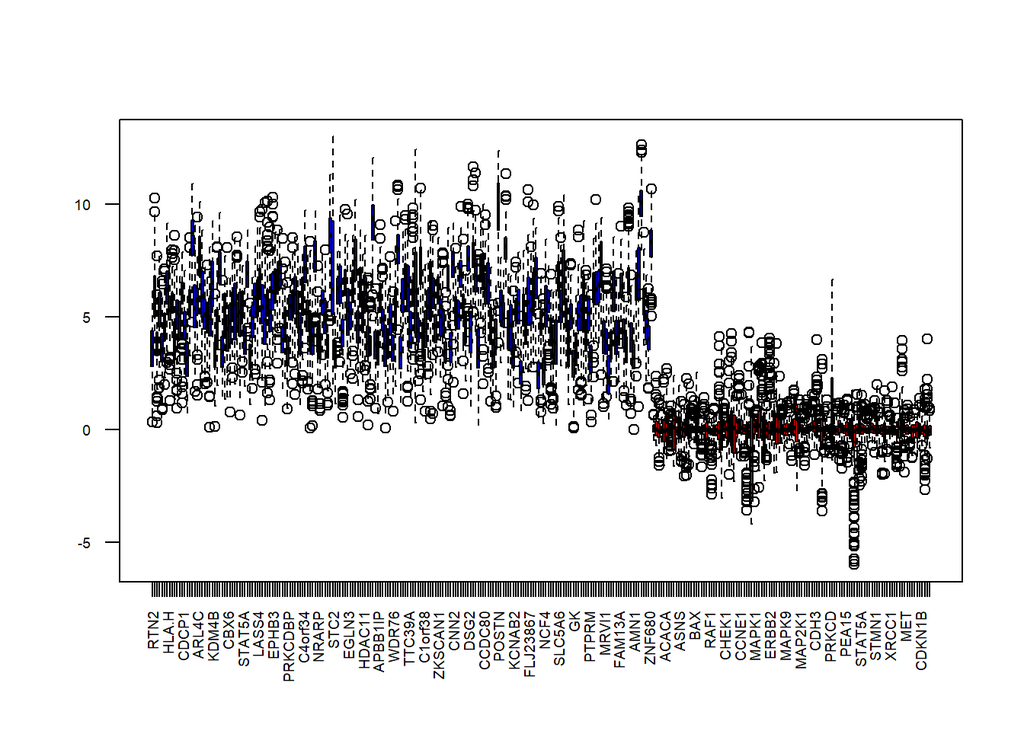

```r
pal <- c(rep("blue",numGenes), rep("red", numProts))
boxplot(jointBasicData, col=pal, cex.axis=0.6, las=2)
```

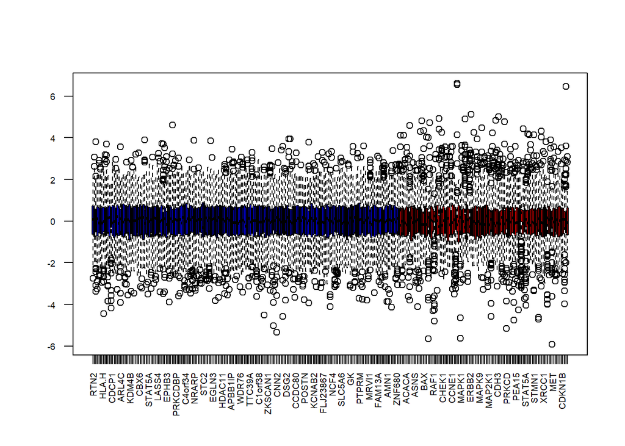

```r
boxplot(jointBasicDataScaled, col=pal, cex.axis=0.6, las=2)
```

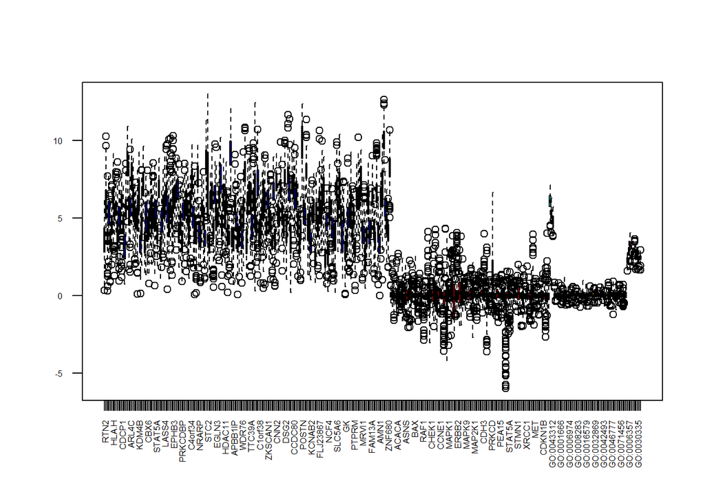

```r
pal <- c(rep("blue",numGenes), rep("red", numProts),
         rep("cyan", numGOsInGenes), rep("orange", numGOsInProts),
         rep("darkmagenta", numGOsInCommon))
boxplot(jointExpandedData, col=pal, cex.axis=0.5, las=2)
```

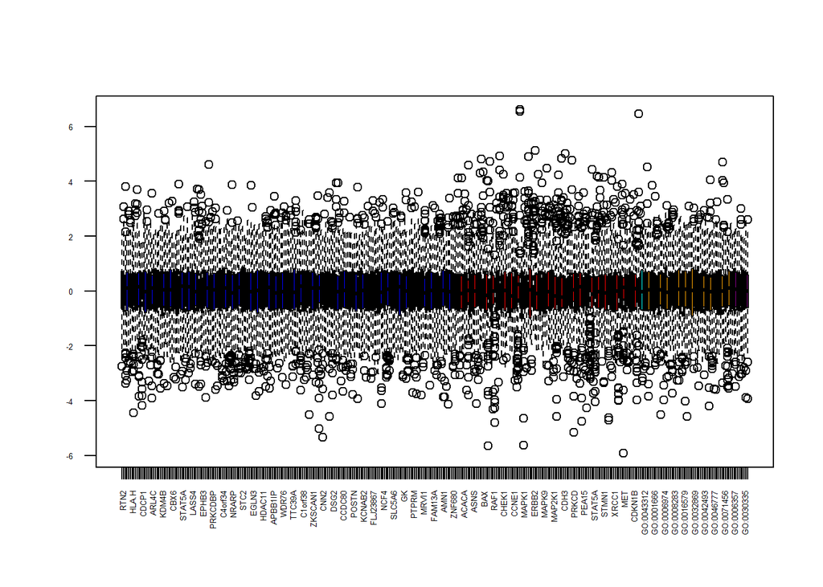

```r
boxplot(jointExpandedDataScaled, col=pal, cex.axis=0.4, las=2)
```

# Applying MFA to basic data

MFA is applied on the “basic” matrix formed only by expressions, that has been previously scaled.

```r
require(FactoMineR)
```

```r
res.mfa.b <- MFA (base=jointBasicDataScaled,
                      group=grupsBasic,
                      name.group = names(grupsBasic),
                      type=basicTypes,
                      graph=FALSE)
```

```r
dimdesc(res.mfa.b)
```

## Representation of Groups

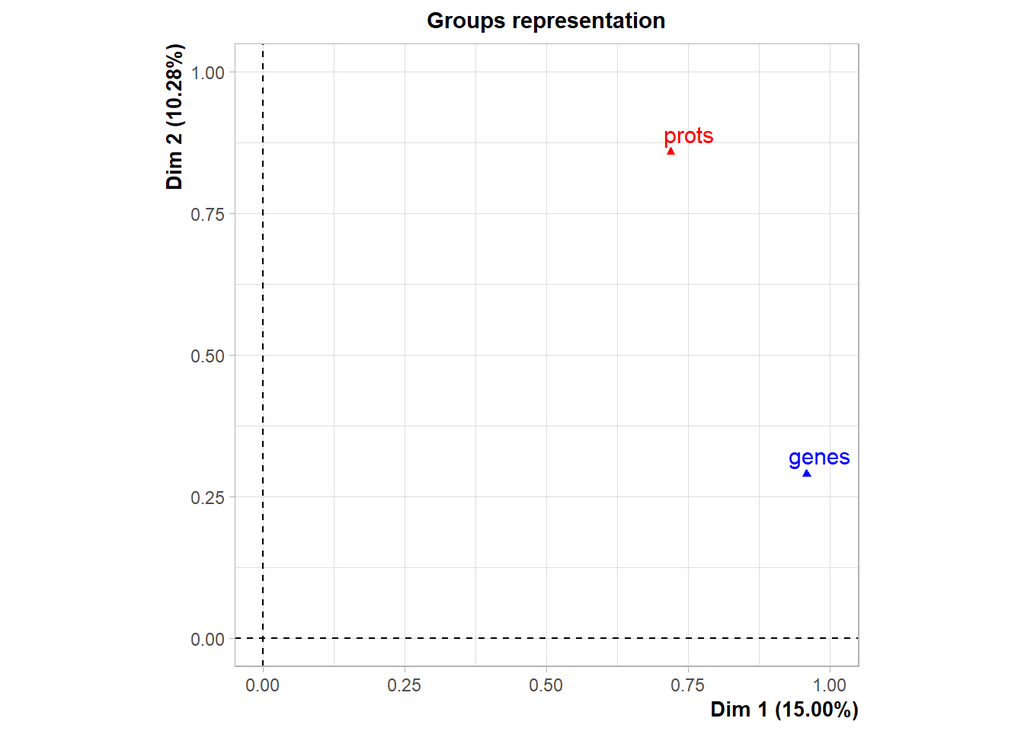

```r
plot(res.mfa.b,choix="group", palette=c("red", "blue"))
```

## Study of individuals and variables

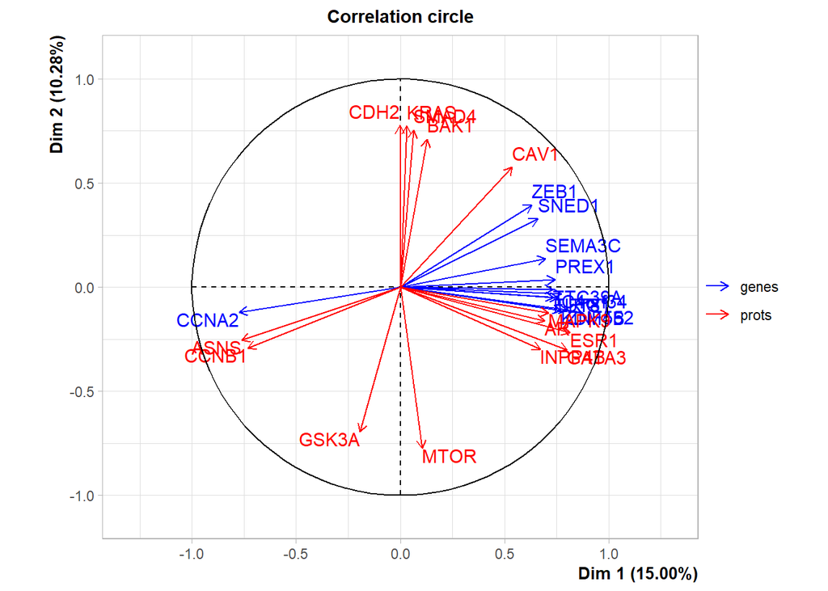

```r
plot(res.mfa.b, choix="var",
     #invisible="quanti.sup",
     hab="group",
     lab.var=TRUE, lim.cos2.var = 0.5,
     palette=c("black","blue", "red"))
```

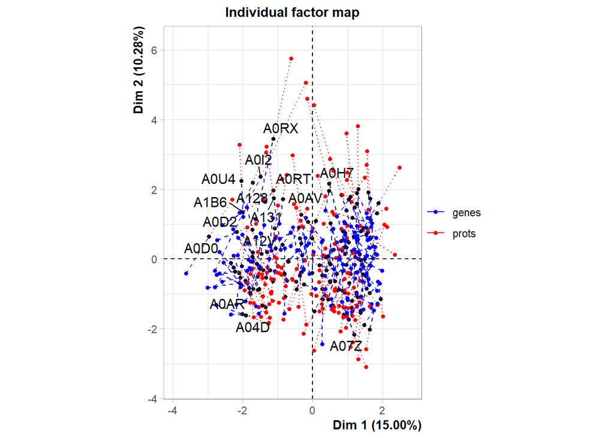

```r
plot(res.mfa.b,choix="ind",partial="all",habillage="group",palette=c("black","blue", "red"))
```

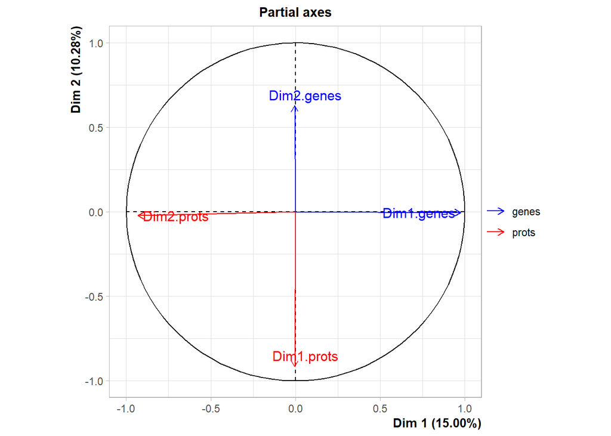

```r
plot(res.mfa.b,choix="axes",habillage="group",palette=c("black","blue", "red"))
```

## Indivuals analysis with factoextra

Habillage parameter sets the phenotypes (= cancer subtypes)

```r
library(factoextra)
```

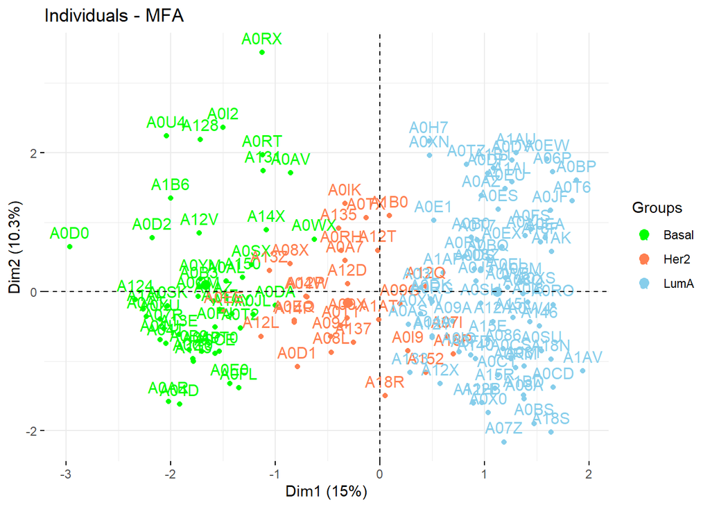

```r
# Variables
#fviz_mfa_var(res.mfa.b, palette = ...)

# Individuals
pal <- c("green", "coral", "skyblue")
fviz_mfa_ind(res.mfa.b, habillage = brca.subtype, palette = pal) # color by cancer subtype
```

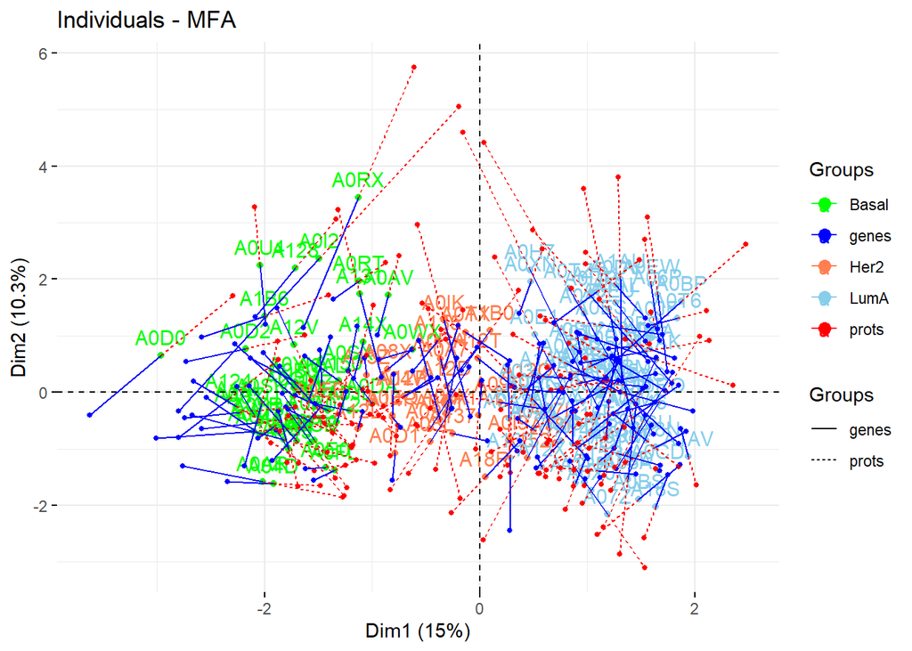

```r
# Individuals with all vars
pal <- c("green", "blue", "coral", "skyblue", "red")
fviz_mfa(res.mfa.b, habillage = brca.subtype, palette = pal)# color by groups
```

# Applying MFA to expanded data

MFA is applied on the “expanded” matrix formed by expressions and annotations, that has been previously scaled.

```r
require(FactoMineR)
res.mfa.x<- MFA (base=jointExpandedDataScaled,
                      group=grupsExpanded,
                      name.group = names(grupsExpanded),
                      type=expandedTypes,
                      num.group.sup = supplGroups, graph=FALSE)
```

```r
dimdesc(res.mfa.x)
```

## Representation of Groups

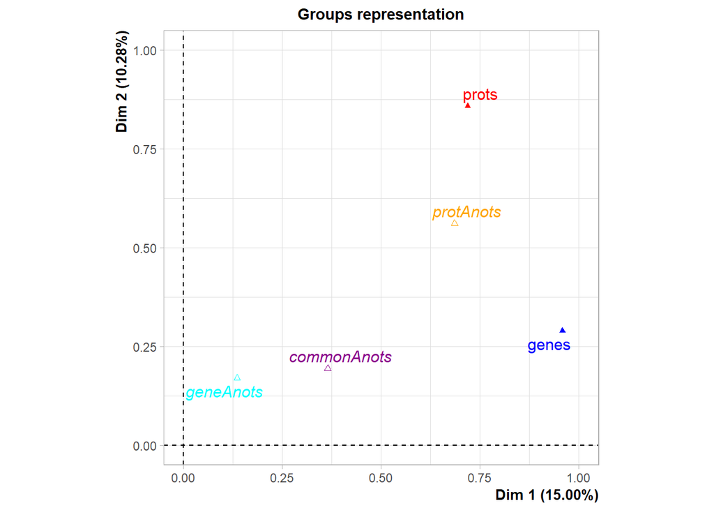

```r
pal <- c("darkmagenta", "blue", "red", "cyan", "orange")
plot(res.mfa.x,choix="group", palette=pal)
```

## Study of individuals and variables

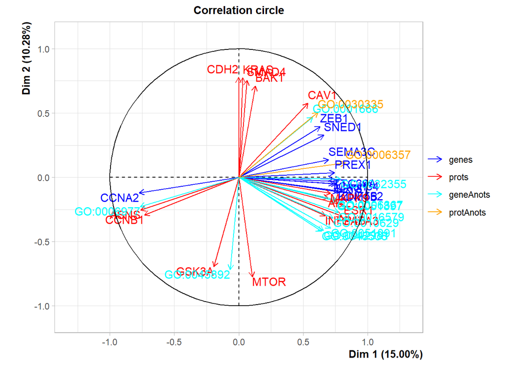

```r
pal <- c("darkmagenta", "blue", "red", "cyan", "orange")
plot(res.mfa.x, choix="var",
     #invisible="quanti.sup",
     hab="group",
     lab.var=TRUE, lim.cos2.var = 0.5,
     palette=pal)
```

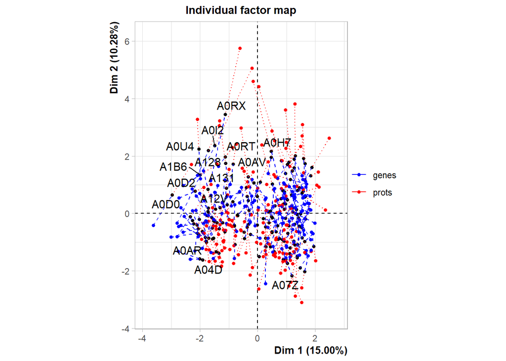

```r
plot(res.mfa.x,choix="ind",partial="all",habillage="group",palette=c("black", "blue", "red"))
```

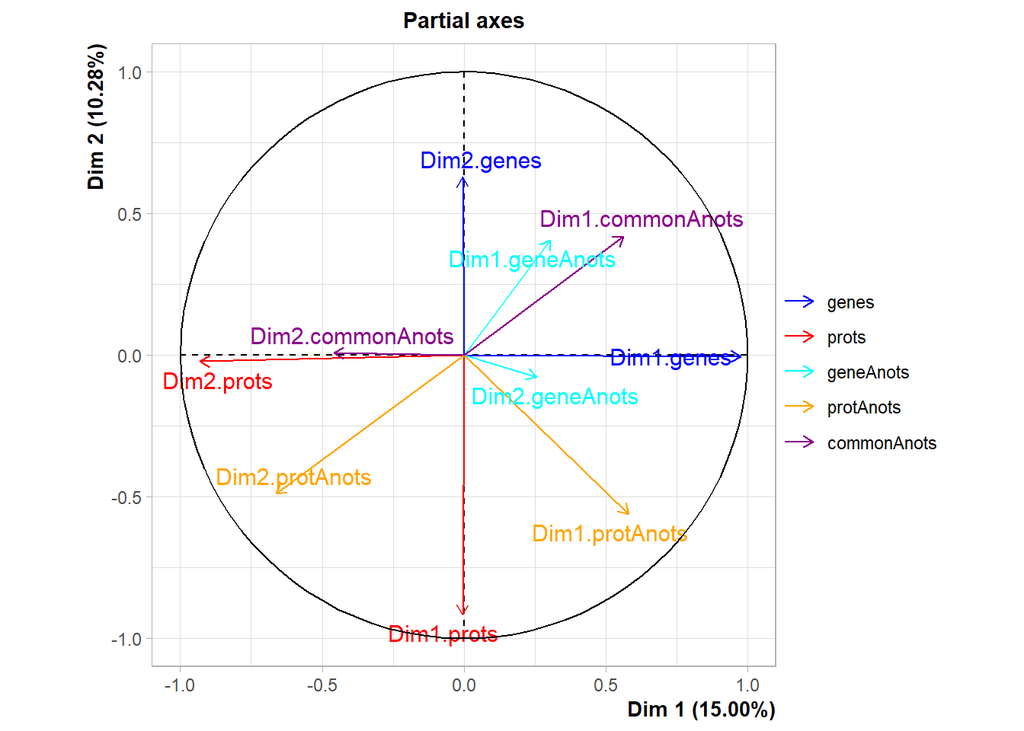

```r
pal <- c("black", "blue", "red", "cyan", "orange", "darkmagenta")
plot(res.mfa.x,choix="axes",habillage="group",palette=pal)
```

## Indivuals analysis with factoextra

Habillage parameter sets the phenotypes (= cancer subtypes)

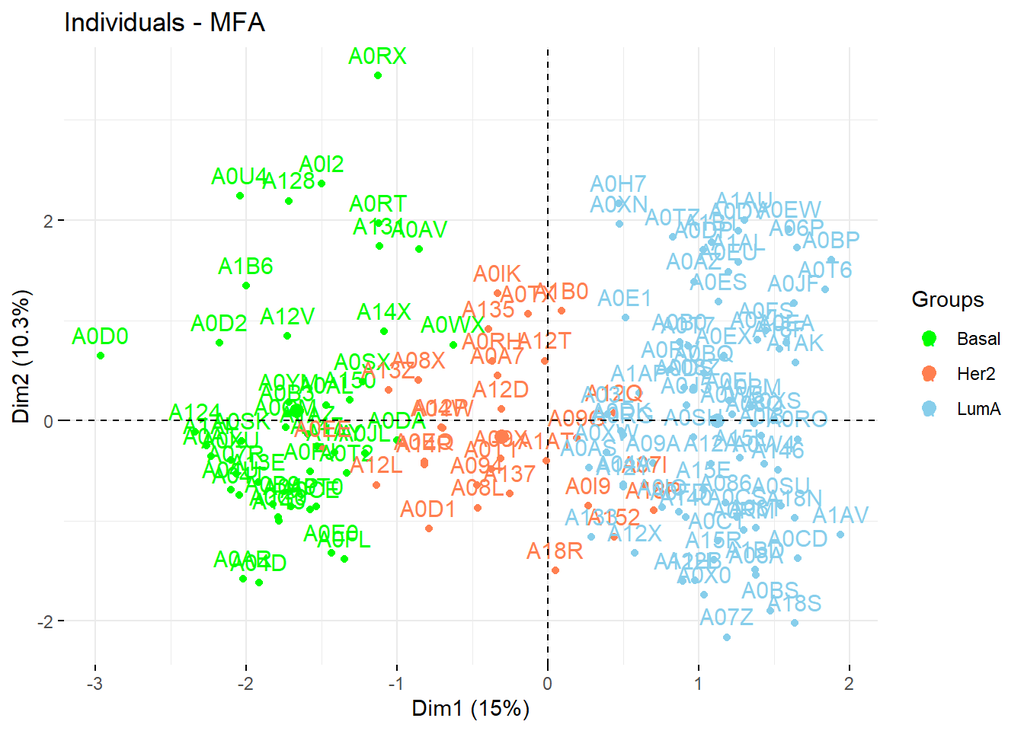

```r
library(factoextra)

# Variables
#fviz_mfa_var(res.mfa.x, palette = ...)

# Individuals
pal <- c("green", "coral", "skyblue")
fviz_mfa_ind(res.mfa.x, habillage = brca.subtype, palette = pal) # color by cancer subtype
```

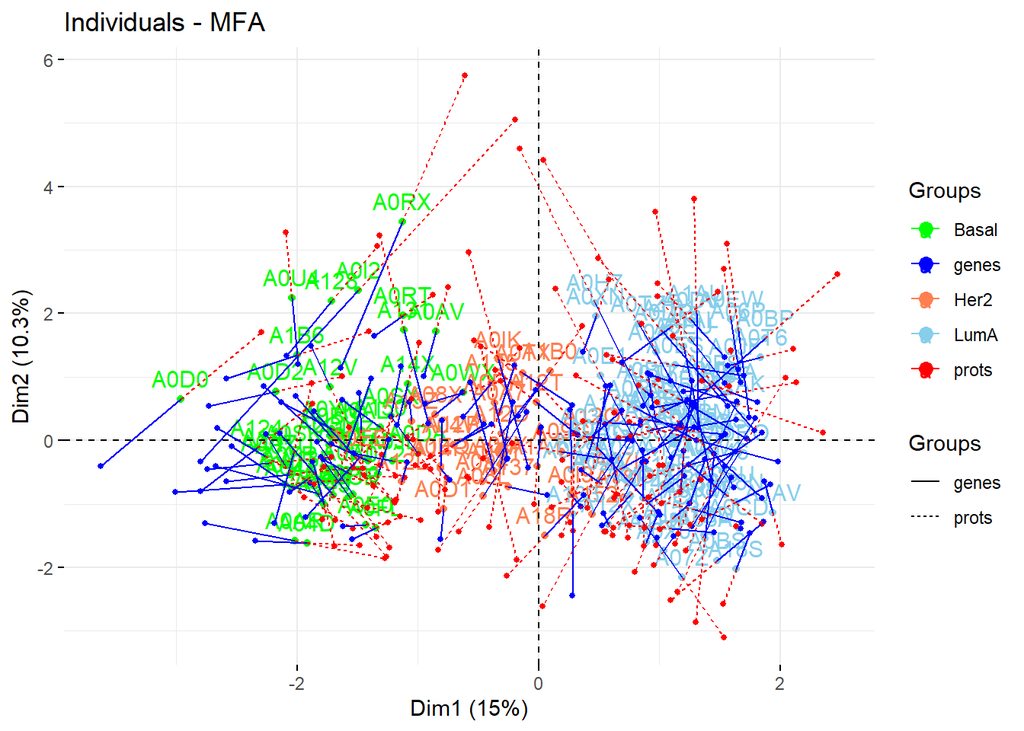

```r
# Individuals with all vars
pal <- c("green", "blue", "coral", "skyblue", "red")
fviz_mfa(res.mfa.x, habillage = brca.subtype, palette =  pal)# color by groups
```

# MFA redefining active/supplem. data

Now, we consider the group of features created from common annotations between genes and proteins also as principal data to the MFA analysis.

As said before, supplementary groups are described by the index of the group in the vector that defines how many variables in each groups. In this case, we remove group 5 from the supplementary list.

```r
new.supplGroups <- c(3,4)
```

MFA is applied on the “expanded” matrix formed by expressions and annotations, that has been previously scaled.

```r
require(FactoMineR)
res.mfa.x2 <- MFA (base=jointExpandedDataScaled,
                      group=grupsExpanded,
                      name.group = names(grupsExpanded),
                      type=expandedTypes,
                      num.group.sup = new.supplGroups, graph=FALSE)
```

```r
dimdesc(res.mfa.x2)
```

## Representation of Groups

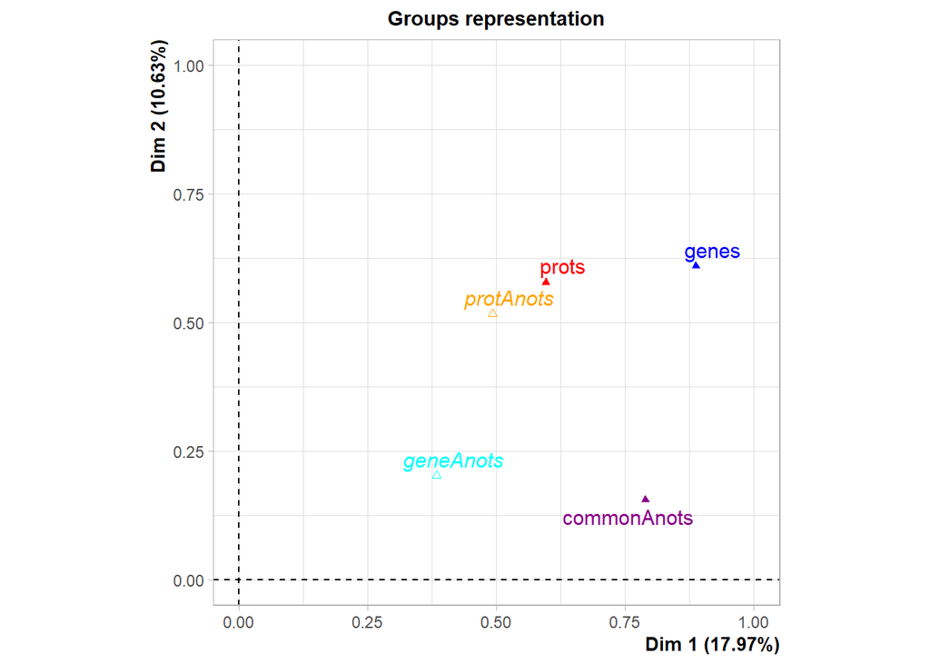

```r
pal <- c("orange", "blue", "red", "darkmagenta", "cyan")
plot(res.mfa.x2,choix="group", palette=pal)
```

## Study of individuals and variables

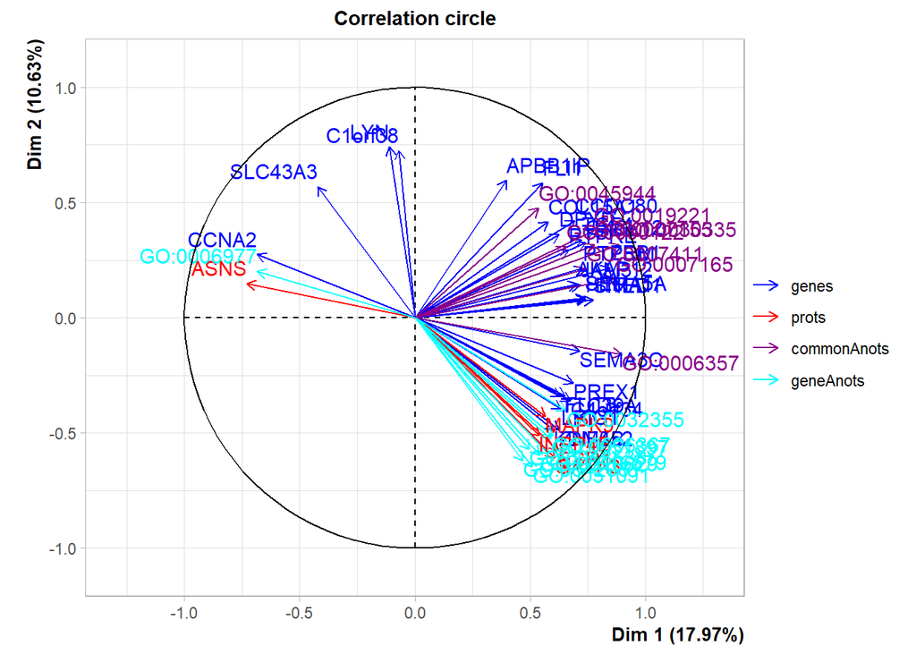

```r
pal <- c("orange", "blue", "red", "darkmagenta", "cyan")
plot(res.mfa.x2, choix="var",
     #invisible="quanti.sup",
     hab="group",
     lab.var=TRUE, lim.cos2.var = 0.5,
     palette=pal)
```

Common annotations

GO:0019221 = cytokine-mediated signaling pathway GO:0007165 = signal transduction GO:0006357 = regulation of transcription by RNA polymerase II GO:0045944 = positive regulation of transcription by RNA polymerase II

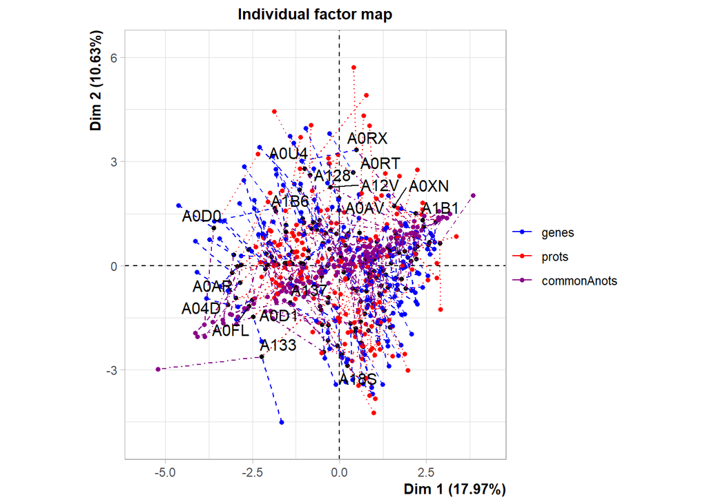

```r
pal <- c("black", "blue", "red", "darkmagenta")
plot(res.mfa.x2,choix="ind",partial="all",habillage="group",palette=pal)
```

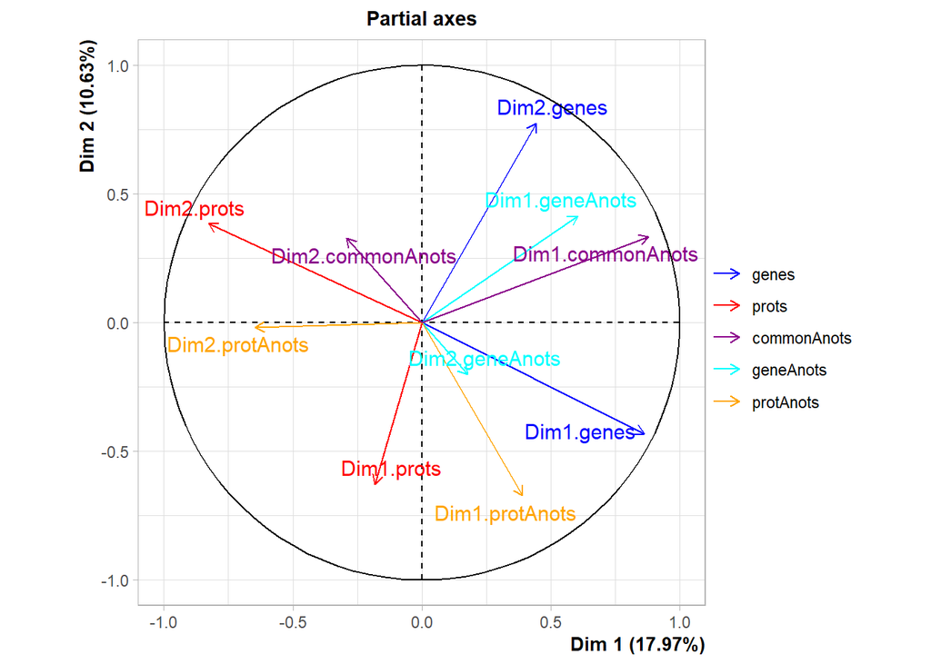

```r
pal <- c("black", "blue", "red", "darkmagenta", "cyan", "orange")
plot(res.mfa.x2,choix="axes",habillage="group",palette=pal)
```

## Indivuals analysis with factoextra

Habillage parameter sets the phenotypes (= cancer subtypes)

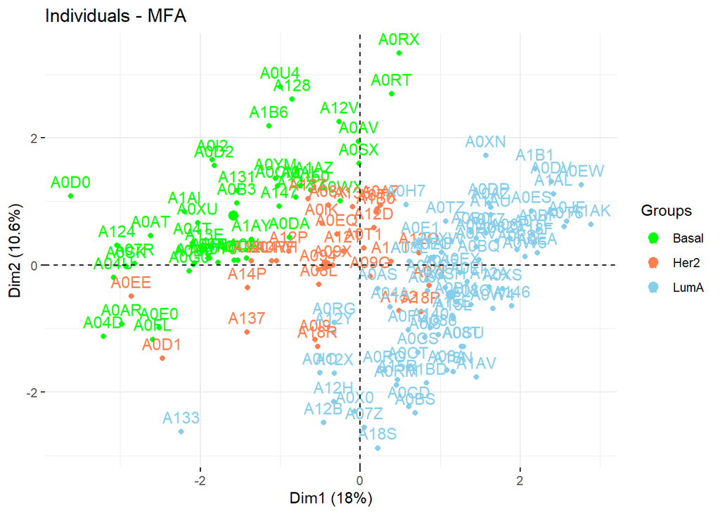

```r
library(factoextra)

# Variables
#fviz_mfa_var(res.mfa.x, palette = ...)

# Individuals
pal <- c("green", "coral", "skyblue")
fviz_mfa_ind(res.mfa.x2, habillage = brca.subtype, palette = pal) # color by cancer subtype
```

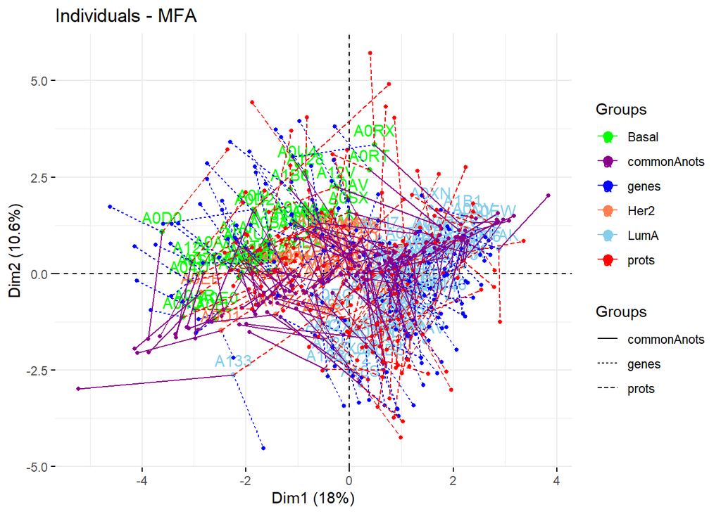

```r
# Individuals with all vars
pal <- c("green", "darkmagenta", "blue", "coral", "skyblue", "red")
fviz_mfa(res.mfa.x2, habillage = brca.subtype, palette =  pal)# color by groups
```